# Funciones de Estadística Parte 2

## Funciones Estadísticas Parte 2

En esta sesión revisaremos las siguientes funciones. Estas son funciones que son empleadas en la mayoría de investigaciones:

- Prueba de contraste de medias t-test
- Prueba de proporciones
- Prueba de correlación y sus gráficos

## Prueba de contraste de medias

El coeficiente t es un ratio entre la diferencia de medias entres dos muestras y el error stándar de ambas muestras, es decir, la varianza no explicada.

Esta es una prueba fundamental cuando queremos analizar la diferencia de una variable cuantitatva entre dos muestras. La prueba-t nos ayuda a tener la probabilidad de equivocarnos al aceptar que haya una diferencia entre ambas muestras, lo que se conoce como el *p-value.*

## Ejemplo - Prueba de contraste de medias

Crearemos dos muestras artificiales para probar el contraste de medias.

```r
# Primero simulemos la data
id <- seq(1:200)
set.seed(100) # para fijar los números aleatorios
edad <- sample(c("16-29", "30-44"), 200, replace = TRUE)
sexo <- sample(c("Hombre", "Mujer"), 200, replace = TRUE)
peso <- sample(c(50.5:90.3), 200, replace = TRUE)
altura <- sample(c(152:190), 200, replace = TRUE) |>
  as.numeric()
datos <- data.frame(edad, sexo, peso, altura)
```

```r
# Realicemos la prueba t
prueba_1 <- t.test(peso ~ edad, data = datos)
prueba_1
```

```
##
##  Welch Two Sample t-test
##
## data:  peso by edad
## t = 0.79883, df = 195.79, p-value = 0.4254
## alternative hypothesis: true difference in means between group 16-29 and group 30-44 is not equal to 0
## 95 percent confidence interval:
##  -1.888960  4.461075
## sample estimates:
## mean in group 16-29 mean in group 30-44
##            71.09375            69.80769
```

## Prueba de contraste de medias - Analizando los resultados

```r
# Coeficiente t
prueba_1$statistic
```

```
##         t
## 0.7988315
```

```r
# Valor p, o probabilidad de Error Tipo I
prueba_1$p.value
```

```
## [1] 0.4253561
```

```r
# Intervalo de cofianza al 95%
prueba_1$conf.int
```

```
## [1] -1.888960  4.461075
## attr(,"conf.level")
## [1] 0.95
```

## Prueba de Proporciones

No todas las variables con las que trabajamos son númericas. Muchas veces solo tenemos frecuencias de variables categóricas las cuales también pueden ser sometidad a una hipótesis.

Para eso existe la prueba de proporciones, nos da el Error Tipo I (p-value) entre la frecuencia de dos muestras.

Es una prueba muy útil para hallar diferencias significativas entre grupos y reportarlas en nuestros trabajos.

## Ejemplo Prueba de Proporciones

Sigamos usando la base de datos que hemos creado. Haremos el contraste si la proporción de hombres es similar a la de mujeres. Utilizaremos la función “prop.test”.

```r
# primero separamos los grupos y contabilizamos la frecuencia total y las frecuencias de cada grupo

library(dplyr)

n_total <- nrow(datos) # frequencia total
hombres <- nrow(filter(datos, sexo == "Hombre")) # frecuencia hombres
mujeres <- nrow(filter(datos, sexo == "Mujer")) # frecuencia mujeres

# ahora podemos realizar nuestra  prueba
prueba_2 <- prop.test(c(hombres, mujeres), # los grupos a evaluar
                      c(n_total, n_total)) # el n de la muestra
```

## Prueba de proporciones analizando resultados

```r
# Coeficiente z
prueba_2$statistic
```

```
## X-squared
##      0.01
```

```r
# Valor p, o probabilidad de Error Tipo I
prueba_2$p.value
```

```
## [1] 0.9203443
```

```r
# Intervalo de cofianza al 95%
prueba_2$conf.int
```

```
## [1] -0.0929933  0.1129933
## attr(,"conf.level")
## [1] 0.95
```

## Prueba de Correlaciones y Gráfico - Parte 1

En nuestra base tenemos dos medidas cuantitativas, peso y altura. Creemos dos variables nuevas y hagamos una prueba de correlación entre las cuatro variables.

```r
# creemos niveles de glucosa y colesterol (ml)
set.seed(100)
glucosa <- sample(c(138.5:160), 200, replace = TRUE)
colesterol <- sample(c(137.5:200), 200, replace = TRUE)

# juntemos con nuestra base anterior
datos_2 <- cbind(datos, glucosa, colesterol)

datos_2
```

```
##      edad   sexo peso altura glucosa colesterol
## 1   30-44  Mujer 82.5    181   147.5      156.5
## 2   16-29  Mujer 74.5    168   143.5      154.5
## 3   30-44 Hombre 70.5    182   153.5      192.5
## 4   30-44 Hombre 51.5    163   156.5      137.5
## 5   16-29  Mujer 71.5    160   151.5      172.5
## 6   16-29 Hombre 56.5    153   149.5      194.5
## 7   30-44  Mujer 61.5    164   159.5      174.5
## 8   30-44  Mujer 50.5    157   143.5      192.5
## 9   30-44 Hombre 67.5    162   141.5      179.5
## 10  16-29  Mujer 62.5    167   143.5      147.5
## 11  30-44 Hombre 54.5    164   139.5      197.5
## 12  30-44  Mujer 89.5    165   144.5      155.5
## 13  30-44 Hombre 73.5    182   144.5      190.5
## 14  30-44  Mujer 68.5    189   148.5      178.5
```

[output cut: 186 more lines]

## Prueba de Correlaciones y Gráfico - Parte 2

Ahora realizaremos la prueba de correlación de nuestras cuatro variables y trataremos de graficarla.

```r
library(corrplot) # para poder graficar
prueba_cor <- cor(datos_2[,c(3:6)])

# Imprimir nuestros resultados

round(prueba_cor,2)
```

```
##             peso altura glucosa colesterol
## peso        1.00  -0.01   -0.07      -0.10
## altura     -0.01   1.00   -0.01      -0.07
## glucosa    -0.07  -0.01    1.00      -0.04
## colesterol -0.10  -0.07   -0.04       1.00
```

## Prueba de Correlaciones y Gráfico - Parte 3

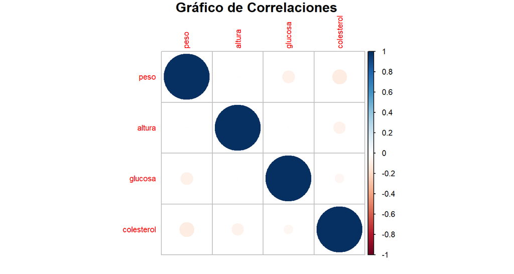

```r
# Ahora hagamos el gráfico
library(corrplot) # para poder graficar
grafico <- corrplot(prueba_cor, method = "circle", title = "Gráfico de Correlaciones",
                    mar = c(1,1,1,1),
                    tl.cex = 0.7,
                    cl.cex = 0.7,
                    cl.align.text = "l")
```